# Regression modelling

### Anova

An anova comparison below between model_3 and the step model using a Chi-squared test shows a small p value for the stepped model - indicating that the model is an improvement. F-test can be used on continuous response models.

```r
anova(model_3,step_model_sick, test="Chisq")
```

```
Analysis of Deviance Table

Model 1: inc_count_sick ~ age + policy_year + sex + waiting_period
Model 2: inc_count_sick ~ age + waiting_period + sex + smoker + sum_assured
  Resid. Df Resid. Dev Df Deviance  Pr(>Chi)
1    449992      20032
2    449990      19995  2   36.795 1.023e-08 ***
---
Signif. codes:  0 '***' 0.001 '**' 0.01 '*' 0.05 '.' 0.1 ' ' 1
```

### Likelihood ratio test

The [likelihood ratio test](https://en.wikipedia.org/wiki/Likelihood-ratio_test) compares two models based upon log likelihoods; more at Piet de Jong, Gillian Z. Heller (2008), p74.

The test below concludes that the step model is more accurate than the less complex model.

```r
lrtest(model_3,step_model_sick)
```

```
Likelihood ratio test

Model 1: inc_count_sick ~ age + policy_year + sex + waiting_period
Model 2: inc_count_sick ~ age + waiting_period + sex + smoker + sum_assured
  #Df   LogLik Df  Chisq Pr(>Chisq)
1   8 -10016.1
2  10  -9997.7  2 36.795  1.023e-08 ***
---
Signif. codes:  0 '***' 0.001 '**' 0.01 '*' 0.05 '.' 0.1 ' ' 1
```

### Other tests

Other validations tests could be considered like the [Wald test](https://en.wikipedia.org/wiki/Wald_test), [Score test](https://en.wikipedia.org/wiki/Score_test); see Piet de Jong, Gillian Z. Heller (2008), p74-77.

## Residual checks

Residuals/ errors are the observed less fitted values. Traditional residual plots (shown below) are usually a good starting point (we expect to see no trend in the plot of residuals vs fitted values), but are not as informative for logistic regression or for data with a low probability outcome.

### Standard model plots

Plots, linear regression example:

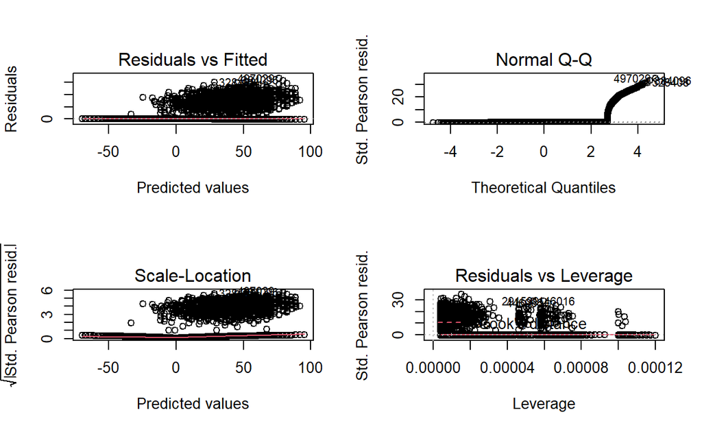

```r
par(mfrow = c(2, 2))
plot(amount_model_3)
```

Logistic regression example:

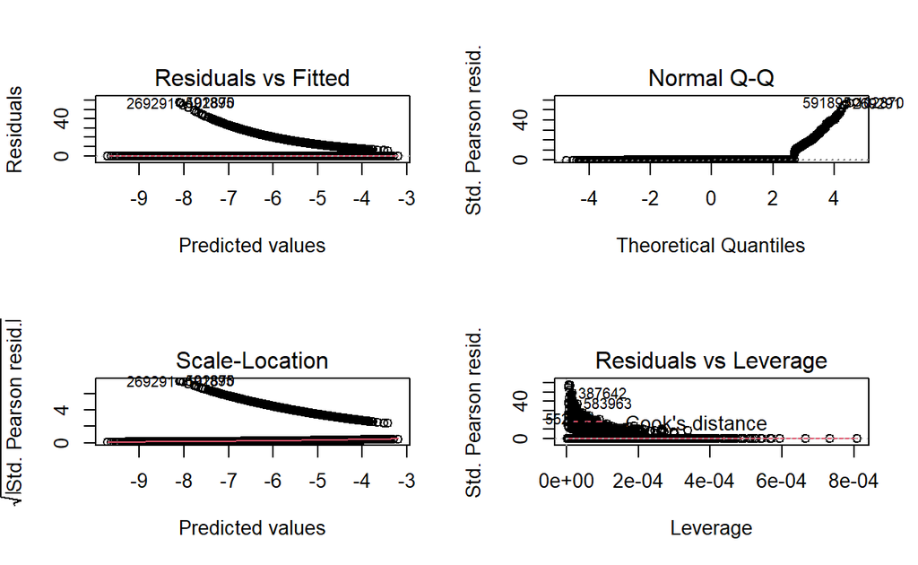

```r
par(mfrow = c(2, 2))
plot(step_model_sick)
```

### Alternatives

For logistic regression we can try other tools to test the residuals against the model assumptions. GLMs assume that the residuals/ errors are normally distributed. Plotting the density of the residuals gives us:

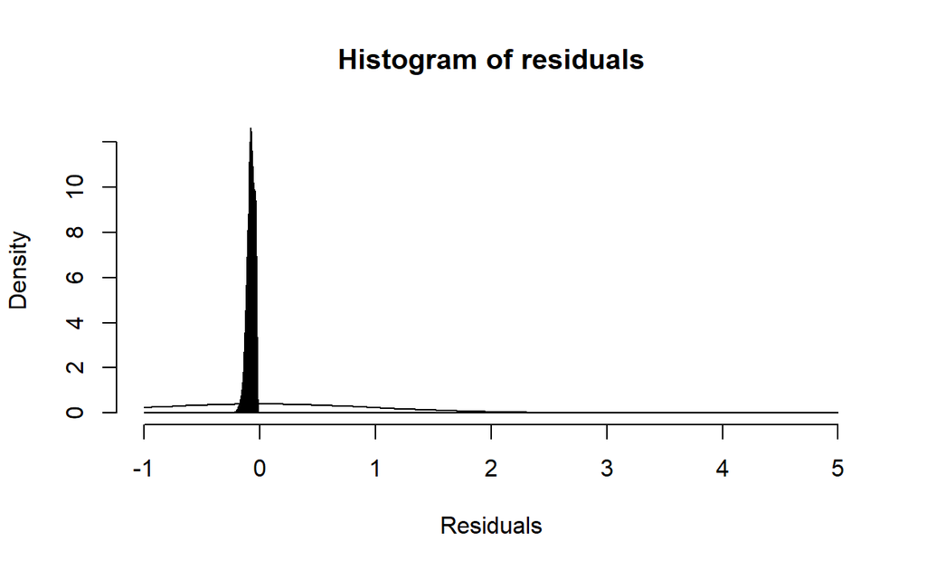

```r
hist(rstandard(step_model_sick),breaks= c(seq(-1,1,by=0.001),seq(2,5, by=1)),freq=FALSE,main = "Histogram of residuals",xlab = "Residuals")
curve(dnorm, add = TRUE)
```

Focusing the x axis range:

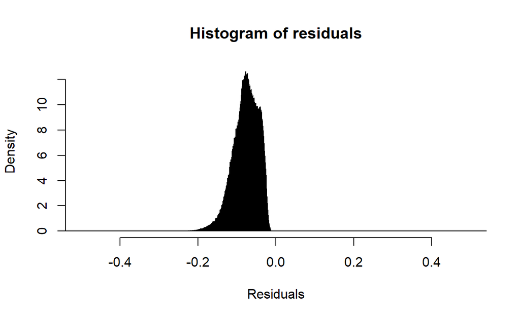

```r
hist(rstandard(step_model_sick),breaks= c(seq(-1,1,by=0.001),seq(2,5, by=1)), xlim = c(-0.5,0.5),freq=FALSE,main = "Histogram of residuals",xlab = "Residuals")
```

A binned residual plot divides data into bins based upon their fitted values, showing the average residuals vs fitted value for each bin (Jeff Webb 2017):

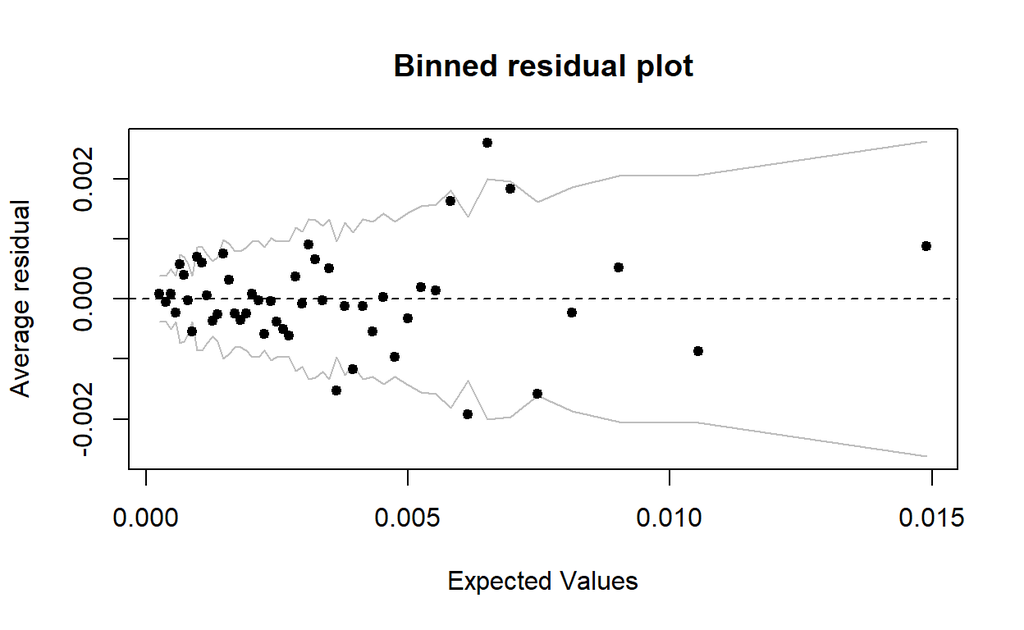

```r
# from the arm package
binnedplot(fitted(step_model_sick),
           residuals(step_model_sick, type = "response"),
           nclass = 50,
           xlab = "Expected Values",
           ylab = "Average residual",
           main = "Binned residual plot",
           cex.pts = 0.8,
           col.pts = 1,
           col.int = "gray")
```

Grey lines are 2 se bands (~95%). Apart from a few outliers, most of the residuals are within those bands.

### P-P plots

The P-P (probability–probability) plot is a visualization that plots CDFs of the two distributions (empirical and theoretical) against each other, an unrelated dummy example below. It can be used to assess the residuals for normality.

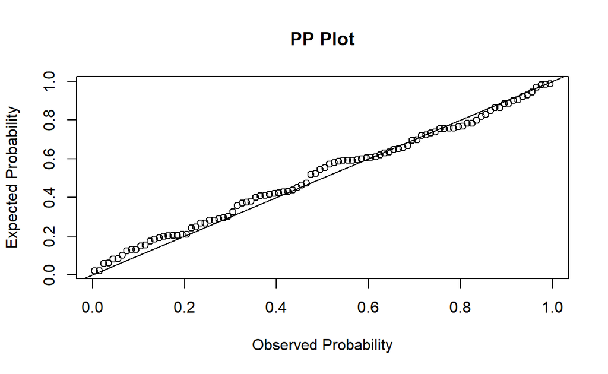

```r
x <- rnorm(100)
probDist <- pnorm(x)
#create PP plot
plot(ppoints(length(x)), sort(probDist), main = "PP Plot", xlab = "Observed Probability", ylab = "Expected Probability")
#add diagonal line
abline(0,1)
```

### Other tests

[Pearson dispersion test](https://search.r-project.org/CRAN/refmans/msme/html/P__disp.html): This function calculates Pearson Chi2 statistic and the Pearson-based dipersion statistic. Values of the dispersion greater than 1 indicate model overdispersion. Values under 1 indicate under-dispersion.

```r
P__disp(step_model_sick)
```

```
pearson.chi2   dispersion
457855.78948      1.01748
```

## Confusion matrix

With a binary prediction from the model loaded within the dataframe (defined earlier), we can compare this to the actual outcomes to determine the validity of the model. In this comparison, the true positive rate is called the Sensitivity. The inverse of the false-positive rate is called the Specificity.

- Sensitivity = TruePositive / (TruePositive + FalseNegative)
- Specificity = TrueNegative / (FalsePositive + TrueNegative)

Where:

- Sensitivity = True Positive Rate
- Specificity = 1 – False Positive Rate

A perfect classification model could have Sensitivity and Specificity close to 1. However, we noted earlier, in insurance applications we are not often interested in in an accurate prediction as to whether a given policy gives rise to a claim. Rather we are interested in understanding the claim rates and how they are explained by the response variables/ risk factors (Piet de Jong, Gillian Z. Heller 2008, p108–109).

A confusion matrix is a tabular representation of Observed vs Predicted values. It helps to quantify the efficiency (or accuracy) of the model.

```r
confusion_matrix <- df_test_pred %>% select(inc_count_sick,pred_inc_count_sick) %>% table()
confusion_matrix
```

```
              pred_inc_count_sick
inc_count_sick      0      1
             0 239855 208606
             1    808    731
```

```r
cat("Accuracy Rate =",(confusion_matrix[1,1]+confusion_matrix[2,2])/sum(confusion_matrix[]),
"; Missclasification Rate =",(confusion_matrix[1,2]+confusion_matrix[2,1])/sum(confusion_matrix[]),
"; True Positive Rate/Sensitivity  =",confusion_matrix[2,2]/sum(confusion_matrix[2,]))
```

```
Accuracy Rate = 0.5346356 ; Missclasification Rate = 0.4653644 ; True Positive Rate/Sensitivity  = 0.4749838
```

```r
cat("False Positive Rate =",confusion_matrix[1,2]/sum(confusion_matrix[1,]),
"; Specificity =",1-confusion_matrix[1,2]/sum(confusion_matrix[1,]))
```

```
False Positive Rate = 0.4651597 ; Specificity = 0.5348403
```

## ROC/ AUC

The ROC (Receiver Operating Characteristic) curve is a graph with:

- The x-axis showing the False Positive Rate
- The y-axis showing the True Positive Rate

ROC curves start at 0 on the x and y axis and rise to 1. The faster the curve reaches a True Positive Rate of 1, the better the curve generally. A model on the diagonal is only showing a 50/50 chance of correctly guessing the probability of claim. Area under an ROC curve (AUC) is a measure of the usefulness of a model in general, where a greater area means more useful. AUC is a tool for comparing models (generally, the closer the AUC is to 1, the better, but there are some cases where AUC can be misleading; AUC = 0.5 is a model on the diagonal).

In our binary model, the AUC is not much better than 0.5, indicating a very weak predictive ability. It isn’t hugely surprising that our model is not very effective at predicting individual claims. As noted earlier, for insurance applications, we are usually more concerned with predicting the claim rate and how it varies by predictors like age and sex (Piet de Jong, Gillian Z. Heller 2008, p108–109).

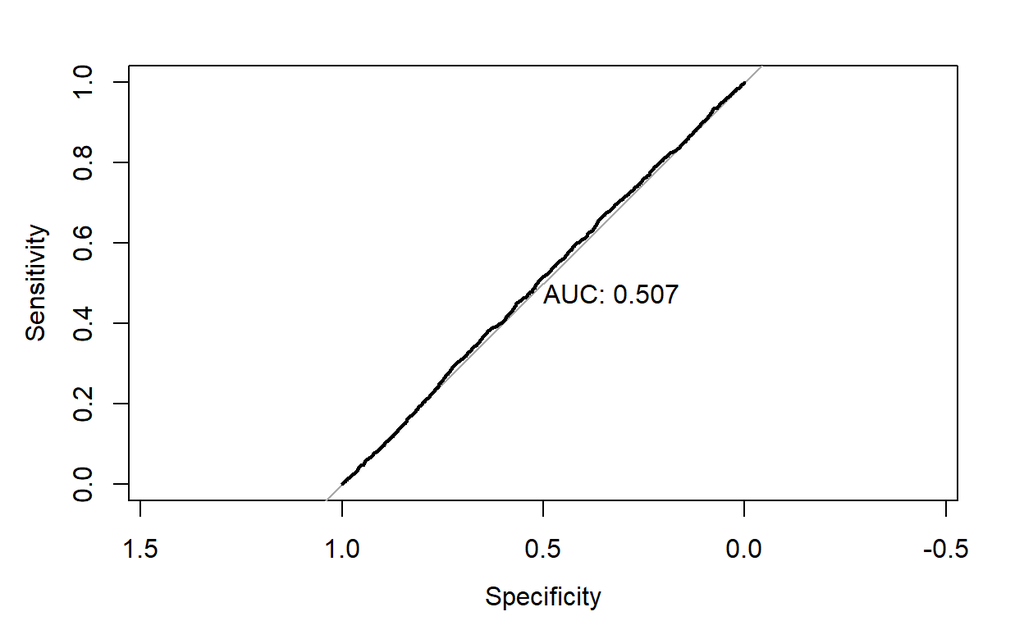

```r
par(mfrow = c(1,1))
roc = roc(df_test_pred$inc_count_sick, df_test_pred$pred_rate_inc_count_sick, plot = TRUE, print.auc = TRUE)
```

```r
as.numeric(roc$auc)
```

```
[1] 0.5074699
```

```r
coords(roc, "best", ret = "threshold")
```

```
    threshold
1 0.001932091
```

# References

Jeff Webb. 2017. “Statistics and Predictive Analytics.” https://bookdown.org/jefftemplewebb/IS-6489/logistic-regression.html#assessing-logistic-model-fit.

Piet de Jong, Gillian Z. Heller. 2008. *Generalised Linear Models for Insurance Data*. Cambridge University Press. https://ggplot2.tidyverse.org/reference/ggtheme.html.